# 05 playground

```r
library(tidyverse)
library(lme4)
library(lmerTest)
library(HLMdiag)
library(effects)
```

# Routine and emotional dysregulation in children

## playin around

```r
df <- read_csv("https://uoepsy.github.io/data/crqeds.csv")
```

RQ: Are children with more day-to-day routine better at regulating their emotions, while controlling for the type of school children attend (as a proxy for SES)?

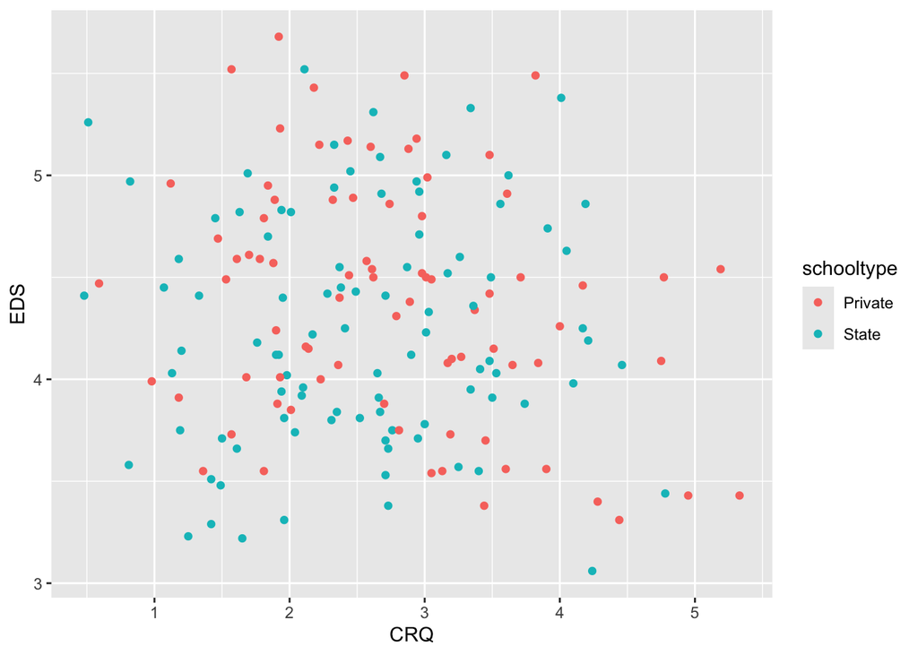

```r
df |>
  ggplot(aes(x = CRQ, y = EDS, colour = schooltype)) +
  geom_point()
```

```r
mod1 <- lmer(EDS ~ schooltype + CRQ +
       (1 + CRQ | schoolid),
       data = df)

summary(mod1)
```

```
## Linear mixed model fit by REML. t-tests use Satterthwaite's method [
## lmerModLmerTest]
## Formula: EDS ~ schooltype + CRQ + (1 + CRQ | schoolid)
##    Data: df
##
## REML criterion at convergence: 289.4
##
## Scaled residuals:
##      Min       1Q   Median       3Q      Max
## -1.85256 -0.84640  0.02332  0.66027  2.04265
##
## Random effects:
##  Groups   Name        Variance Std.Dev. Corr
##  schoolid (Intercept) 0.20734  0.4553
##           CRQ         0.01891  0.1375   -0.76
##  Residual             0.23942  0.4893
## Number of obs: 174, groups:  schoolid, 20
##
## Fixed effects:
##                 Estimate Std. Error       df t value Pr(>|t|)
## (Intercept)      4.53262    0.17583 22.01513  25.778   <2e-16 ***
## schooltypeState -0.16708    0.15415 17.62371  -1.084    0.293
## CRQ             -0.05306    0.05067 15.98435  -1.047    0.311
## ---
## Signif. codes:  0 '***' 0.001 '**' 0.01 '*' 0.05 '.' 0.1 ' ' 1
##
## Correlation of Fixed Effects:
##             (Intr) schltS
## scholtypStt -0.510
## CRQ         -0.762  0.042
```

## phase 1

### Load required R packages and read in data

```r
library(tidyverse)
library(lme4)
library(lmerTest)
library(stats)
library(HLMdiag)
library(effects)

eds_data <- read_csv("https://uoepsy.github.io/data/crqeds.csv")
glimpse(eds_data)
```

```
## Rows: 174
## Columns: 4
## $ schoolid   <chr> "school1", "school1", "school1", "school1", "school1", "sch…
## $ EDS        <dbl> 4.12, 3.22, 4.86, 4.79, 3.58, 4.41, 4.23, 3.66, 4.22, 4.42,…
## $ CRQ        <dbl> 1.92, 1.65, 3.56, 1.45, 0.81, 2.71, 3.01, 1.61, 2.17, 2.28,…
## $ schooltype <chr> "State", "State", "State", "State", "State", "State", "Stat…
```

### Identify fixefs based on RQ

RQ: Are children with more day-to-day routine better at regulating their emotions, while controlling for the type of school children attend (as a proxy for SES)?

Outcome: `EDS` (emotional dysregulation score) Predictors: `CRQ` (childhood routines questionnaire) + `schooltype` (no interaction bc we’re just controlling for this, not looking for how assocs may change)

Fixef model formula: `EDS ~ CRQ + schooltype`

### Plot fixef variables all together

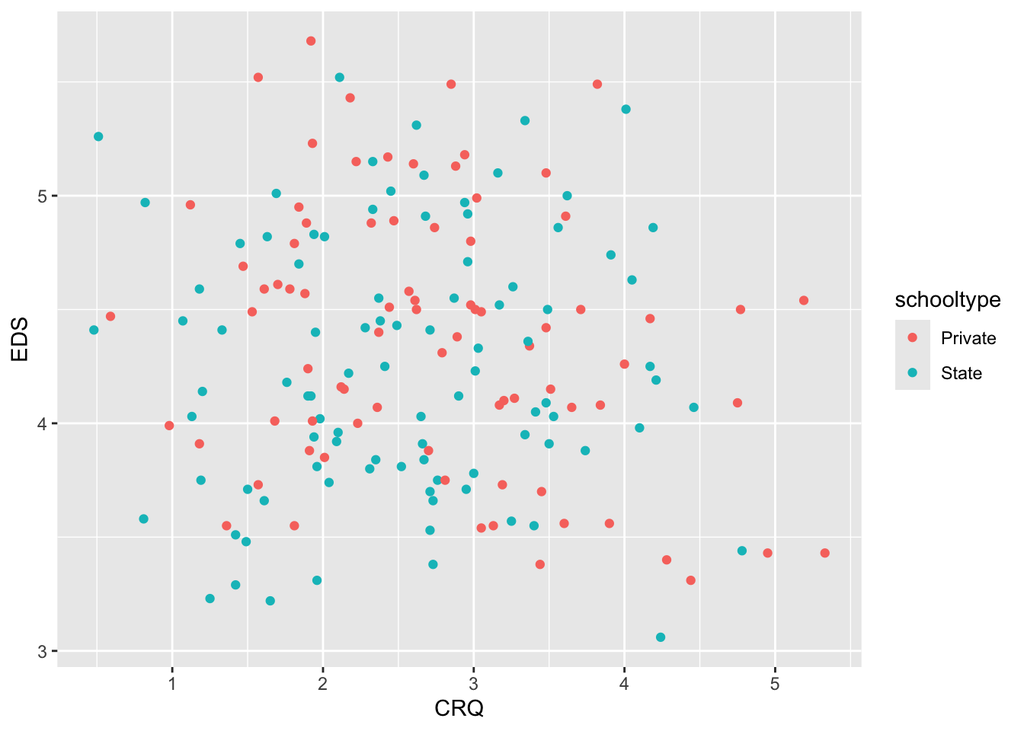

```r
eds_data |>
  ggplot(aes(x = CRQ, y = EDS, colour = schooltype)) +
  geom_point()
```

### Set up categorical (fixed) predictors

```r
eds_data <- eds_data |>
  mutate(
    schooltype = factor(schooltype)
  )

contrasts(eds_data$schooltype)
```

```
##         State
## Private     0
## State       1
```

Ref level of `schooltype`: `Private`

### Set up continuous predictors

```r
eds_data$CRQ
```

```
##   [1] 1.92 1.65 3.56 1.45 0.81 2.71 3.01 1.61 2.17 2.28 2.67 1.98 2.66 1.33 3.53
##  [16] 2.71 2.71 3.48 4.17 2.32 1.88 1.70 3.37 3.45 3.20 2.61 0.98 3.51 1.91 2.37
##  [31] 4.75 1.47 2.44 2.47 5.19 1.57 0.82 2.11 4.01 3.34 2.95 2.96 2.09 4.21 2.96
##  [46] 4.28 1.84 3.60 2.70 2.18 1.61 2.62 4.44 3.05 2.74 3.40 1.49 4.46 2.49 1.42
##  [61] 4.17 4.24 1.25 1.96 3.48 1.92 2.43 0.59 2.60 3.02 1.89 2.94 1.53 3.82 2.87
##  [76] 4.05 2.76 3.17 3.34 1.84 2.41 3.62 3.00 1.90 1.93 4.00 2.22 2.81 2.57 2.01
##  [91] 2.85 1.57 2.79 2.14 1.12 3.19 3.71 2.89 2.88 2.37 3.26 3.25 2.33 1.50 2.52
## [106] 3.36 3.91 0.51 2.31 1.93 3.13 3.84 3.65 2.36 4.77 2.23 1.68 1.13 4.19 2.38
## [121] 1.95 2.35 2.01 2.67 2.45 2.90 2.73 1.63 2.10 3.50 3.49 1.20 0.48 1.76 2.62
## [136] 2.68 3.16 2.33 2.94 1.07 3.74 4.10 1.90 3.90 1.18 2.12 3.17 1.78 3.61 4.95
## [151] 3.44 1.42 1.94 3.41 2.73 1.94 1.69 2.65 3.03 2.04 3.48 4.78 1.18 1.96 1.19
## [166] 2.98 3.01 5.33 2.98 1.81 1.81 3.27 1.36 3.05
```

where does zero fall relative to these values?

zero IS a possible value for the CRQ (it ranges 0 to 7, and 0 means no routine), but we don’t have it in our dataset.

so there’s a reasonable motivation to mean-centre CRQ (make the mean = 0), but also reasonable motivation to keep CRQ as-is (model makes estimates at 0 = people with no routine)

### Identify grouping variables that contribute random variability (these will be random intercepts)

```r
glimpse(eds_data)
```

```
## Rows: 174
## Columns: 4
## $ schoolid   <chr> "school1", "school1", "school1", "school1", "school1", "sch…
## $ EDS        <dbl> 4.12, 3.22, 4.86, 4.79, 3.58, 4.41, 4.23, 3.66, 4.22, 4.42,…
## $ CRQ        <dbl> 1.92, 1.65, 3.56, 1.45, 0.81, 2.71, 3.01, 1.61, 2.17, 2.28,…
## $ schooltype <fct> State, State, State, State, State, State, State, State, Sta…
```

Only remaining var: `schoolid`

```r
eds_data |>
  group_by(schoolid) |>
  count()
```

```
## # A tibble: 20 × 2
## # Groups:   schoolid [20]
##    schoolid     n
##    <chr>    <int>
##  1 school1      9
##  2 school10     6
##  3 school11     9
##  4 school12    10
##  5 school13     8
##  6 school14    10
##  7 school15     7
##  8 school16     8
##  9 school17     9
## 10 school18     4
## 11 school19    10
## 12 school2      8
## 13 school20     9
## 14 school3     10
## 15 school4      9
## 16 school5      9
## 17 school6     10
## 18 school7      9
## 19 school8     10
## 20 school9     10
```

Yes, mult children from ea school. So `schoolid` is a grouping variable.

Does it contribute controlled / reproducible variability or random variability?

If we did this study again, we could sample diff schools. And we want our results to generalise across schools. So it contributes random variability.

That means our model will have random intercepts by `schoolid`.

Model formula so far: `EDS ~ CRQ + schooltype + (1 | schoolid)`

### Identify what random slopes are possible in maximal model

Do at least some levels of each grouping variable appear with more than one value of each predictor?

- Do at least some levels of `schoolid` appear with more than one value of `CRQ`?
- Do at least some levels of `schoolid` appear with more than one value of `schooltype`?

First: Do at least some levels of `schoolid` appear with more than one value of `CRQ`? Yes.

```r
xtabs(~ schoolid + CRQ, data = eds_data)
```

```
##           CRQ
## schoolid   0.48 0.51 0.59 0.81 0.82 0.98 1.07 1.12 1.13 1.18 1.19 1.2 1.25 1.33
##   school1     0    0    0    1    0    0    0    0    0    0    0   0    0    0
##   school10    0    0    0    0    0    0    0    0    0    0    0   0    0    0
##   school11    0    0    0    0    0    0    0    1    0    0    0   0    0    0
##   school12    0    1    0    0    0    0    0    0    0    0    0   0    0    0
##   school13    0    0    0    0    0    0    0    0    0    0    0   0    0    0
##   school14    0    0    0    0    0    0    0    0    1    0    0   0    0    0
##   school15    1    0    0    0    0    0    0    0    0    0    0   1    0    0
##   school16    0    0    0    0    0    0    1    0    0    0    0   0    0    0
##   school17    0    0    0    0    0    0    0    0    0    1    0   0    0    0
##   school18    0    0    0    0    0    0    0    0    0    0    0   0    0    0
##   school19    0    0    0    0    0    0    0    0    0    1    1   0    0    0
##   school2     0    0    0    0    0    0    0    0    0    0    0   0    0    1
##   school20    0    0    0    0    0    0    0    0    0    0    0   0    0    0
##   school3     0    0    0    0    0    1    0    0    0    0    0   0    0    0
##   school4     0    0    0    0    0    0    0    0    0    0    0   0    0    0
##   school5     0    0    0    0    1    0    0    0    0    0    0   0    0    0
##   school6     0    0    0    0    0    0    0    0    0    0    0   0    0    0
##   school7     0    0    0    0    0    0    0    0    0    0    0   0    1    0
##   school8     0    0    1    0    0    0    0    0    0    0    0   0    0    0
##   school9     0    0    0    0    0    0    0    0    0    0    0   0    0    0
##           CRQ
## schoolid   1.36 1.42 1.45 1.47 1.49 1.5 1.53 1.57 1.61 1.63 1.65 1.68 1.69 1.7
##   school1     0    0    1    0    0   0    0    0    1    0    1    0    0   0
##   school10    0    0    0    0    0   0    0    0    0    0    0    0    0   0
##   school11    0    0    0    0    0   0    0    1    0    0    0    0    0   0
##   school12    0    0    0    0    0   1    0    0    0    0    0    0    0   0
##   school13    0    0    0    0    0   0    0    0    0    0    0    1    0   0
##   school14    0    0    0    0    0   0    0    0    0    0    0    0    0   0
##   school15    0    0    0    0    0   0    0    0    0    1    0    0    0   0
##   school16    0    0    0    0    0   0    0    0    0    0    0    0    0   0
##   school17    0    0    0    0    0   0    0    0    0    0    0    0    0   0
##   school18    0    1    0    0    0   0    0    0    0    0    0    0    0   0
##   school19    0    0    0    0    0   0    0    0    0    0    0    0    1   0
##   school2     0    0    0    0    0   0    0    0    0    0    0    0    0   0
##   school20    1    0    0    0    0   0    0    0    0    0    0    0    0   0
##   school3     0    0    0    0    0   0    0    0    0    0    0    0    0   1
##   school4     0    0    0    1    0   0    0    1    0    0    0    0    0   0
##   school5     0    0    0    0    0   0    0    0    0    0    0    0    0   0
```

[output cut: 187 more lines]

```
##   school14    0    0    0    0    0
##   school15    0    0    0    0    0
##   school16    0    0    0    0    0
##   school17    0    0    1    0    0
##   school18    0    0    0    0    0
##   school19    0    1    0    0    0
##   school2     0    0    0    0    0
##   school20    0    0    0    0    1
##   school3     0    0    0    0    0
##   school4     0    0    0    1    0
##   school5     0    0    0    0    0
##   school6     0    0    0    0    0
##   school7     0    0    0    0    0
##   school8     0    0    0    0    0
##   school9     0    0    0    0    0
```

```r
# a trick from the flash cards to count all the non-zero entries in each row:
(xtabs(~ schoolid + CRQ, data = eds_data)  != 0) |>
  rowSums()
```

```
##  school1 school10 school11 school12 school13 school14 school15 school16
##        9        6        9       10        8       10        7        8
## school17 school18 school19  school2 school20  school3  school4  school5
##        9        4       10        7        7       10        9        8
##  school6  school7  school8  school9
##       10        9       10       10
```

So, we can have random slopes over `CRQ` for each `schoolid`.

Second: Do at least some levels of `schoolid` appear with more than one value of `schooltype`?

```r
xtabs(~ schoolid + schooltype, data = eds_data)
```

```
##           schooltype
## schoolid   Private State
##   school1        0     9
##   school10       6     0
##   school11       9     0
##   school12       0    10
##   school13       8     0
##   school14       0    10
##   school15       0     7
##   school16       0     8
##   school17       9     0
##   school18       0     4
##   school19       0    10
##   school2        0     8
##   school20       9     0
##   school3       10     0
##   school4        9     0
##   school5        0     9
##   school6       10     0
##   school7        0     9
##   school8       10     0
##   school9        0    10
```

No! A school is either Private or State.

## phase 2

### fit maximal model

```r
eds_mod <- lmer(
  EDS ~ schooltype + CRQ + (1 + CRQ | schoolid),
  data = eds_data
)
# no warnings, but let's check variance components to make sure we're ok
VarCorr(eds_mod)
```

```
##  Groups   Name        Std.Dev. Corr
##  schoolid (Intercept) 0.45534
##           CRQ         0.13752  -0.758
##  Residual             0.48931
```

Good! model converges + needs no massaging.

## phase 3

### Check assumptions

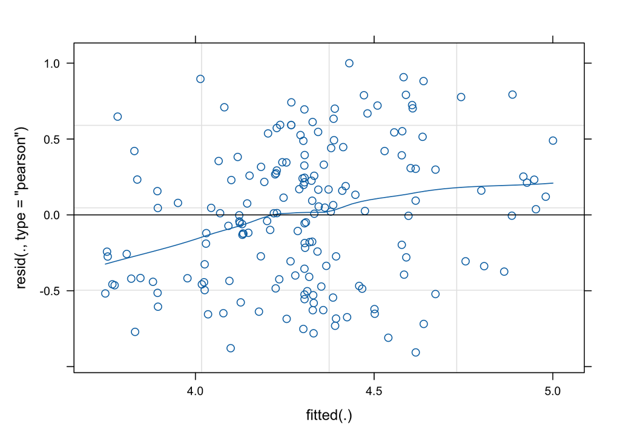

```r
plot(eds_mod,
     type=c(
       "p",      # includes points representing Pearson residuals
       "smooth"  # includes smoothed line representing mean of residuals
       )
    )
```

Could be some deviation from linearity, but oh well. satisfied it’s linear enough that our model will be okay.

Equal variance looks OK.

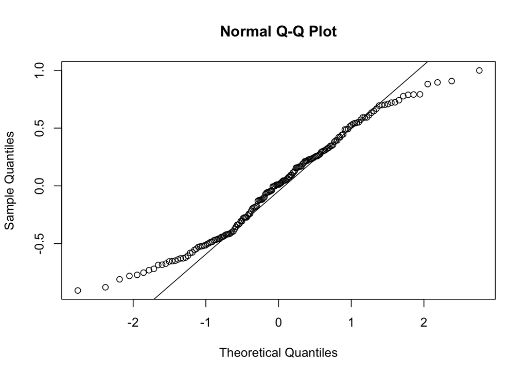

```r
qqnorm(resid(eds_mod)); qqline(resid(eds_mod))
```

oo yes, it’s weird at the extremes. that’s because our outcome variable of EDS is bounded between 1 and 6, which is not something that a linear model can technically handle.

In worlds beyond DAPR, there are ways to model this kind of bounded data properly. But a lot of scientists will still analyse it like this, even though the assumptions aren’t totally supported. So if we accept this assumption, which we will have to in order to use the linear modelling machinery, then we just live with this.

Normality of ranefs:

```r
ranef(eds_mod)$schoolid[,1]  # int
```

```
##  [1] -0.41350197  0.16362990  0.40809586  0.14622992 -0.38971121 -0.01691010
##  [7]  0.02517130  0.49251288 -0.06651435 -0.46919476  0.11457203 -0.09303276
## [13] -0.11564389 -0.02301221 -0.14989050  0.32745977  0.53129688 -0.65256316
## [19]  0.24011086 -0.05910450
```

```r
ranef(eds_mod)$schoolid[,2]  # slp
```

```
##  [1]  0.1418649432 -0.0437141644 -0.0726568041 -0.0258674079  0.0478882349
##  [6]  0.0685230424 -0.0062956726 -0.0424325842 -0.0721963736  0.0522245837
## [11] -0.0722562547 -0.0379843493 -0.0105136870  0.0005117251  0.0370778862
## [16]  0.0271158567 -0.2374982376  0.0809068913  0.1126732684  0.0526291035
```

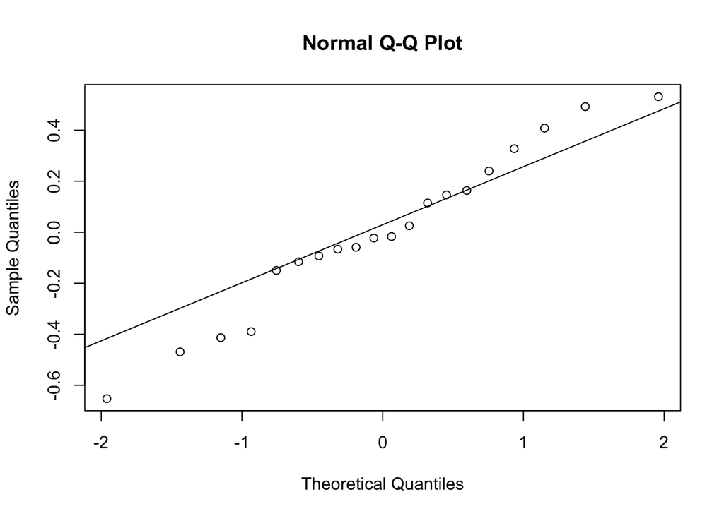

```r
qqnorm(ranef(eds_mod)$schoolid[,1]); qqline(ranef(eds_mod)$schoolid[,1])
```

Some divergence—it’s not as nice as it could be. But not as bad as it could be either.

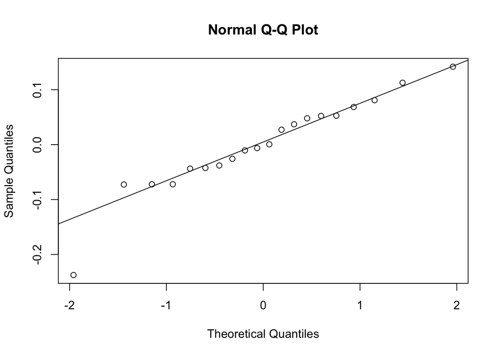

```r
qqnorm(ranef(eds_mod)$schoolid[,2]); qqline(ranef(eds_mod)$schoolid[,2])
```

Better, except for one of the slope adjustments being more negative than we’d expect! Oh well, not bad overall.

### Check influential observations/schools

```r
inf_obs  <- hlm_influence(model = eds_mod, level = 1, approx = TRUE)
inf_schoolid <- hlm_influence(model = eds_mod, level = "schoolid", approx = TRUE)
```

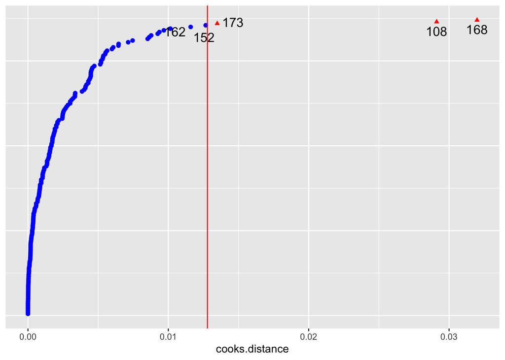

```r
dotplot_diag(inf_obs$cooksd, cutoff = "internal")
```

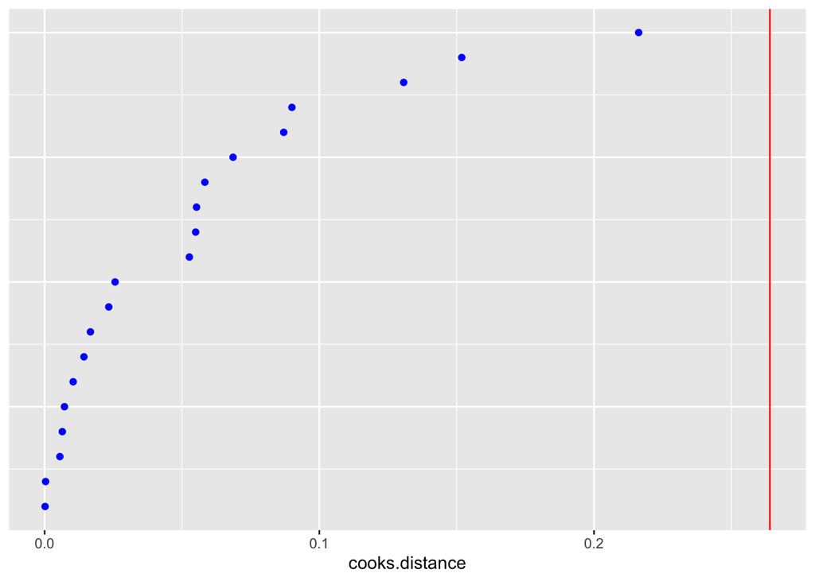

```r
dotplot_diag(inf_schoolid$cooksd, index = inf_schoolid$schoolid, cutoff = "internal")
```

worth doing sensitivity analysis for 108 and 168, potentially, but can set that aside for reasons of time.

#### Sensitivity analysis 168 feat bobyqa

```r
# failed to converge
eds_mod_no168 <- lmer(
  EDS ~ schooltype + CRQ + (1 + CRQ | schoolid),
  data = eds_data[-168,]
)
# add in bobyqa
eds_mod_no168 <- lmer(
  EDS ~ schooltype + CRQ + (1 + CRQ | schoolid),
  data = eds_data[-168,],
  control = lmerControl(optimizer = "bobyqa")  # add in this line
)

# to compare to main model, re-fit that model with bobyqa too
# (we want only one thing to be diff between the models we compare)
eds_mod_bobyqa <- lmer(
  EDS ~ schooltype + CRQ + (1 + CRQ | schoolid),
  data = eds_data,
  control = lmerControl(optimizer = "bobyqa")  # add in this line
)
```

```r
summary(eds_mod_bobyqa)
```

```
## Linear mixed model fit by REML. t-tests use Satterthwaite's method [
## lmerModLmerTest]
## Formula: EDS ~ schooltype + CRQ + (1 + CRQ | schoolid)
##    Data: eds_data
## Control: lmerControl(optimizer = "bobyqa")
##
## REML criterion at convergence: 289.4
##
## Scaled residuals:
##      Min       1Q   Median       3Q      Max
## -1.85250 -0.84638  0.02329  0.66026  2.04268
##
## Random effects:
##  Groups   Name        Variance Std.Dev. Corr
##  schoolid (Intercept) 0.20727  0.4553
##           CRQ         0.01891  0.1375   -0.76
##  Residual             0.23943  0.4893
## Number of obs: 174, groups:  schoolid, 20
##
## Fixed effects:
##                 Estimate Std. Error       df t value Pr(>|t|)
## (Intercept)      4.53264    0.17582 22.01953  25.780   <2e-16 ***
## schooltypeState -0.16710    0.15413 17.62760  -1.084    0.293
## CRQ             -0.05306    0.05067 15.98616  -1.047    0.311
## ---
## Signif. codes:  0 '***' 0.001 '**' 0.01 '*' 0.05 '.' 0.1 ' ' 1
##
## Correlation of Fixed Effects:
##             (Intr) schltS
## scholtypStt -0.510
## CRQ         -0.762  0.042
```

```r
summary(eds_mod_no168)
```

```
## Linear mixed model fit by REML. t-tests use Satterthwaite's method [
## lmerModLmerTest]
## Formula: EDS ~ schooltype + CRQ + (1 + CRQ | schoolid)
##    Data: eds_data[-168, ]
## Control: lmerControl(optimizer = "bobyqa")
##
## REML criterion at convergence: 285.5
##
## Scaled residuals:
##     Min      1Q  Median      3Q     Max
## -1.8898 -0.8306  0.0255  0.6474  2.0038
##
## Random effects:
##  Groups   Name        Variance Std.Dev. Corr
##  schoolid (Intercept) 0.26243  0.5123
##           CRQ         0.02601  0.1613   -0.81
##  Residual             0.23244  0.4821
## Number of obs: 173, groups:  schoolid, 20
##
## Fixed effects:
##                 Estimate Std. Error       df t value Pr(>|t|)
## (Intercept)      4.49965    0.18376 22.32374  24.486   <2e-16 ***
## schooltypeState -0.17209    0.15373 17.68793  -1.119    0.278
## CRQ             -0.03706    0.05464 16.20756  -0.678    0.507
## ---
## Signif. codes:  0 '***' 0.001 '**' 0.01 '*' 0.05 '.' 0.1 ' ' 1
##
## Correlation of Fixed Effects:
##             (Intr) schltS
## scholtypStt -0.483
## CRQ         -0.786  0.035
```

no big diff.

#### Sensitivity analysis 108

```r
eds_mod_no108 <- lmer(
  EDS ~ schooltype + CRQ + (1 + CRQ | schoolid),
  data = eds_data[-108,]
)

summary(eds_mod_no108)
```

```
## Linear mixed model fit by REML. t-tests use Satterthwaite's method [
## lmerModLmerTest]
## Formula: EDS ~ schooltype + CRQ + (1 + CRQ | schoolid)
##    Data: eds_data[-108, ]
##
## REML criterion at convergence: 285
##
## Scaled residuals:
##      Min       1Q   Median       3Q      Max
## -1.88478 -0.84648  0.02644  0.66408  2.04264
##
## Random effects:
##  Groups   Name        Variance Std.Dev. Corr
##  schoolid (Intercept) 0.23142  0.4811
##           CRQ         0.02285  0.1512   -0.78
##  Residual             0.23280  0.4825
## Number of obs: 173, groups:  schoolid, 20
##
## Fixed effects:
##                 Estimate Std. Error       df t value Pr(>|t|)
## (Intercept)      4.49653    0.17950 21.24985  25.050   <2e-16 ***
## schooltypeState -0.17874    0.15417 17.69904  -1.159    0.262
## CRQ             -0.03857    0.05284 16.25092  -0.730    0.476
## ---
## Signif. codes:  0 '***' 0.001 '**' 0.01 '*' 0.05 '.' 0.1 ' ' 1
##
## Correlation of Fixed Effects:
##             (Intr) schltS
## scholtypStt -0.495
## CRQ         -0.773  0.035
```

no difference

### plot model estimates

```r
effect(term = c("CRQ", 'schooltype'), mod = eds_mod) |>
  as.data.frame()
```

```
## NOTE: CRQschooltype does not appear in the model
```

```
##    CRQ schooltype      fit        se    lower    upper
## 1  0.5    Private 4.506094 0.1573744 4.195448 4.816741
## 2  2.0    Private 4.426507 0.1184040 4.192786 4.660229
## 3  3.0    Private 4.373450 0.1152119 4.146029 4.600870
## 4  4.0    Private 4.320392 0.1329035 4.058049 4.582734
## 5  5.0    Private 4.267334 0.1648883 3.941855 4.592812
## 6  0.5      State 4.339016 0.1456134 4.051585 4.626448
## 7  2.0      State 4.259430 0.1070115 4.048196 4.470663
## 8  3.0      State 4.206372 0.1066271 3.995897 4.416847
## 9  4.0      State 4.153314 0.1281502 3.900354 4.406274
## 10 5.0      State 4.100256 0.1631284 3.778251 4.422261
```

CRQ is spaced kind of weird, so let’s give it a diff vector of CRQ values

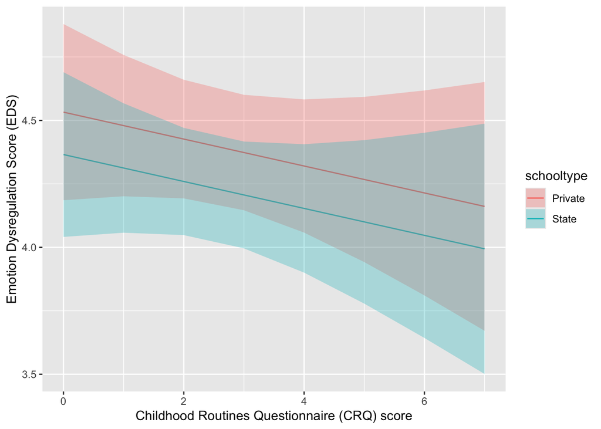

```r
effect(term = c("CRQ", 'schooltype'), mod = eds_mod, xlevels = list(CRQ = 0:7)) |>
  as.data.frame() |>
  ggplot(aes(x = CRQ, y = fit)) +
  geom_line(aes(colour = schooltype)) +
  geom_ribbon(aes(ymin = lower, ymax = upper, fill = schooltype), alpha = 0.3) +
  labs(
    y = 'Emotion Dysregulation Score (EDS)',
    x = 'Childhood Routines Questionnaire (CRQ) score'
  )
```

## interpret fixefs

```r
# summary(eds_mod)
fixef(eds_mod) |> round(2)
```

```
##     (Intercept) schooltypeState             CRQ
##            4.53           -0.17           -0.05
```

`(Intercept)`: The average estimated emotional dysregulation for pupils in private schools with CRQ = 0 (that is, zero routine) is 4.53 points.

```r
effect(term = c("CRQ", 'schooltype'), mod = eds_mod, xlevels = list(CRQ = 0:7)) |>
  as.data.frame() |>
  ggplot(aes(x = CRQ, y = fit)) +
  geom_line(aes(colour = schooltype)) +
  geom_ribbon(aes(ymin = lower, ymax = upper, fill = schooltype), alpha = 0.3) +
  labs(
    y = 'Emotion Dysregulation Score (EDS)',
    x = 'Childhood Routines Questionnaire (CRQ) score'
  ) +
  geom_point(x = 0, y = 4.53, size = 5)  # plot the intercept
```

[output not shown]

`schooltypeState`: Holding CRQ constant (ie, for any value of CRQ), moving from private schools to state schools is associated with a decrease of EDS of 0.17. That is, dysregulation decreases, or regulation increases. This difference is not significantly different from zero.

`CRQ`: Holding school type constant (ie, for any value of school type), an increase of one CRQ point is associated with a decrease of EDS of 0.05. That is, dysregulation decreases, or regulation increases. This difference is also not significantly different from zero.

## interpret ranefs relative to fixefs

```r
VarCorr(eds_mod)
```

```
##  Groups   Name        Std.Dev. Corr
##  schoolid (Intercept) 0.45534
##           CRQ         0.13752  -0.758
##  Residual             0.48931
```

The by-school intercept adjustments have a SD of 0.46 points. Thus the model suggests that 95% of the adjusted school-level intercepts fall between 4.53 – 2 * 0.46 = 3.61 and 4.53 + 2 * 0.46 = 5.45 EDS points.

The intercept and slope adjustments have a fairly large negative correlation of –0.75. This suggests that schools that tend to have students with higher emotional dysregulation scores (big intercept) tend to have a more negative adjustment to the slope of `CRQ`. Since this fixed slope is already negative, the more negative adjustments suggest that the effect of `CRQ` tends to be stronger in schools with pupils having higher emotional dysregulation.

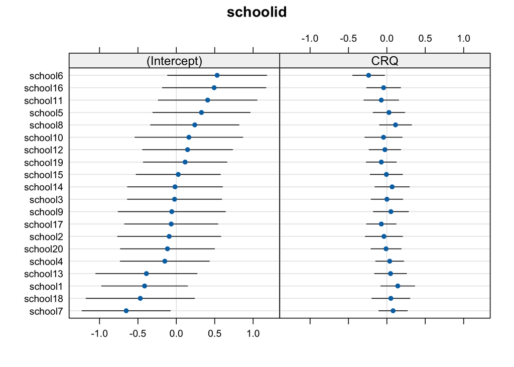

```r
dotplot.ranef.mer(ranef(eds_mod))$schoolid
```

## Advanced: plot the random effect lines

to sense check our interpretation of the negative correlation

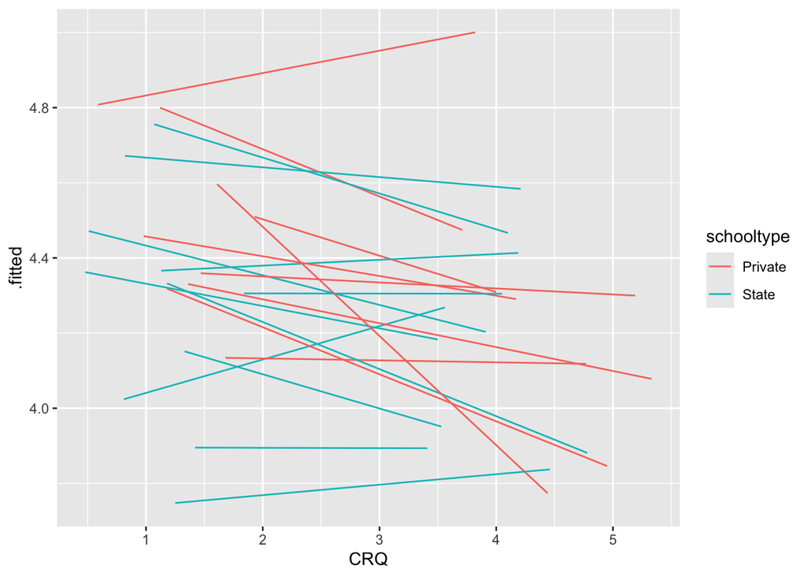

```r
library(broom.mixed)

augment(eds_mod) |>
  ggplot(aes(x = CRQ, y = .fitted, group = schoolid, colour = schooltype)) +
  geom_line()
```

# stress and CBD drinks

## playin around

```r
unique(df$pid)
```

```r
df <- read_csv("https://uoepsy.github.io/data/stressweek1.csv")
# re-center 'day' so the intercept is day 1
# df$day <- df$day-1

glimpse(df)
```

```
## Rows: 100
## Columns: 6
## $ dept    <chr> "Psych", "Psych", "Psych", "Psych", "Psych", "Psych", "Psych",…
## $ pid     <chr> "Holly", "Holly", "Holly", "Holly", "Holly", "Tom", "Tom", "To…
## $ CBD     <chr> "N", "N", "N", "N", "N", "Y", "Y", "Y", "Y", "Y", "N", "N", "N…
## $ measure <chr> "Self-report", "Self-report", "Self-report", "Self-report", "S…
## $ day     <dbl> 1, 2, 3, 4, 5, 1, 2, 3, 4, 5, 1, 2, 3, 4, 5, 1, 2, 3, 4, 5, 1,…
## $ stress  <dbl> -0.417, 0.924, 0.634, 1.212, 0.506, -0.557, -0.036, -0.349, -0…
```

```r
staff_gender <- tibble(
  pid = unique(df$pid),
  gender = c( 'F', 'M', 'M', 'M', 'F', 'M', 'M', 'M', 'M', 'F', 'F', 'F', 'M', 'M', 'F', 'M', 'M', 'F', 'F', 'M' )
)

df <- df |>
  merge(staff_gender, by = 'pid')
```

RQ: Does consuming CBD drinks affect Psych staff members’ stress levels across the working week, when controlling for staff members’ gender?

```r
mod1 <- lmer(stress ~ 1 + day * CBD + gender+
               (1 + day | pid),
             data = df)

summary(mod1)
```

```
## Linear mixed model fit by REML. t-tests use Satterthwaite's method [
## lmerModLmerTest]
## Formula: stress ~ 1 + day * CBD + gender + (1 + day | pid)
##    Data: df
##
## REML criterion at convergence: 128.1
##
## Scaled residuals:
##      Min       1Q   Median       3Q      Max
## -2.22841 -0.62920 -0.00912  0.62977  1.79389
##
## Random effects:
##  Groups   Name        Variance Std.Dev. Corr
##  pid      (Intercept) 0.197762 0.44470
##           day         0.004327 0.06578  -0.07
##  Residual             0.112460 0.33535
## Number of obs: 100, groups:  pid, 20
##
## Fixed effects:
##             Estimate Std. Error       df t value Pr(>|t|)
## (Intercept)  0.16234    0.19910 19.45419   0.815  0.42473
## day          0.07567    0.03461 18.00087   2.186  0.04225 *
## CBDY         0.14081    0.26878 17.48127   0.524  0.60693
## genderM     -0.19727    0.22678 16.99722  -0.870  0.39649
## day:CBDY    -0.19128    0.05850 18.00087  -3.270  0.00426 **
## ---
## Signif. codes:  0 '***' 0.001 '**' 0.01 '*' 0.05 '.' 0.1 ' ' 1
##
## Correlation of Fixed Effects:
##          (Intr) day    CBDY   gendrM
## day      -0.399
## CBDY     -0.371  0.295
## genderM  -0.613  0.000 -0.148
## day:CBDY  0.236 -0.592 -0.499  0.000
```

# Needless Game Violence

## playin around

```r
ngv <- read_csv('https://uoepsy.github.io/data/NGV.csv')
```

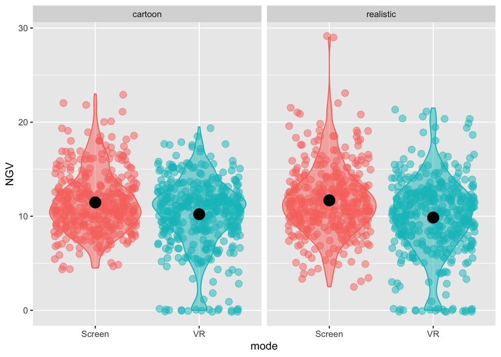

```r
ngv |>
  ggplot(aes(x = mode, y = NGV, fill = mode, colour = mode)) +
  geom_violin(alpha = 0.5) +
  geom_jitter(alpha = 0.5, size = 3) +
  stat_summary(fun = mean, geom = 'point', colour = 'black', size = 5) +
  facet_wrap(~ character) +
  theme(legend.position = 'none')
```

```r
m <- lmer(NGV ~ character * mode + (1 + character | PID) +  (1 + mode | level), data = ngv)
summary(m)
```

```
## Linear mixed model fit by REML. t-tests use Satterthwaite's method [
## lmerModLmerTest]
## Formula: NGV ~ character * mode + (1 + character | PID) + (1 + mode |
##     level)
##    Data: ngv
##
## REML criterion at convergence: 6558.7
##
## Scaled residuals:
##     Min      1Q  Median      3Q     Max
## -3.0127 -0.6229  0.0116  0.6014  3.9530
##
## Random effects:
##  Groups   Name               Variance Std.Dev. Corr
##  PID      (Intercept)        9.11575  3.0192
##           characterrealistic 1.81787  1.3483   0.16
##  level    (Intercept)        0.06482  0.2546
##           modeVR             0.05411  0.2326   -0.51
##  Residual                    3.32606  1.8237
## Number of obs: 1520, groups:  PID, 76; level, 10
##
## Fixed effects:
##                           Estimate Std. Error      df t value Pr(>|t|)
## (Intercept)                11.4676     0.5117 76.6391  22.410   <2e-16 ***
## characterrealistic          0.2216     0.2591 73.9976   0.855   0.3950
## modeVR                     -1.2560     0.7093 75.1164  -1.771   0.0806 .
## characterrealistic:modeVR  -0.5678     0.3616 73.9976  -1.570   0.1207
## ---
## Signif. codes:  0 '***' 0.001 '**' 0.01 '*' 0.05 '.' 0.1 ' ' 1
##
## Correlation of Fixed Effects:
##             (Intr) chrctr modeVR
## chrctrrlstc  0.064
## modeVR      -0.712 -0.046
## chrctrrl:VR -0.046 -0.716  0.064
```

RQ: **How is the realism of games associated with unnecessarily violent gameplay? How is this association impacted by the mode of play (on a screen vs. a virtual reality (VR) headset)?**

## phase 1

### Load required R packages and read in data

```r
library(tidyverse)
library(lme4)
library(lmerTest)
library(HLMdiag)

ngv <- read_csv('https://uoepsy.github.io/data/NGV.csv')
glimpse(ngv)
```

```
## Rows: 1,520
## Columns: 9
## $ PID       <chr> "ppt_1", "ppt_1", "ppt_1", "ppt_1", "ppt_1", "ppt_1", "ppt_1…
## $ age       <dbl> 47, 47, 47, 47, 47, 47, 47, 47, 47, 47, 47, 47, 47, 47, 47, …
## $ level     <chr> "level1", "level9", "level4", "level1", "level4", "level2", …
## $ character <chr> "realistic", "cartoon", "cartoon", "cartoon", "realistic", "…
## $ mode      <chr> "Screen", "Screen", "Screen", "Screen", "Screen", "Screen", …
## $ P         <dbl> 2, 2, 2, 2, 2, 2, 2, 2, 2, 2, 2, 2, 2, 2, 2, 2, 2, 2, 2, 2, …
## $ N         <dbl> 3, 3, 3, 3, 3, 3, 3, 3, 3, 3, 3, 3, 3, 3, 3, 3, 3, 3, 3, 3, …
## $ M         <dbl> 3, 3, 3, 3, 3, 3, 3, 3, 3, 3, 3, 3, 3, 3, 3, 3, 3, 3, 3, 3, …
## $ NGV       <dbl> 10.5, 9.5, 10.0, 10.0, 10.5, 11.5, 11.5, 12.5, 14.5, 15.0, 1…
```

### Identify fixefs based on RQ

RQ: **How is the realism of games associated with unnecessarily violent gameplay? How is this association impacted by the mode of play (on a screen vs. a virtual reality (VR) headset)?**

It is possible to answer these qs with a single model, so that’s what we should do.

Outcome: `NGV` score Predictors: `character`, `mode`, and their interaction

Model formula: `NGV ~ character * mode`

### Plot fixef variables all together

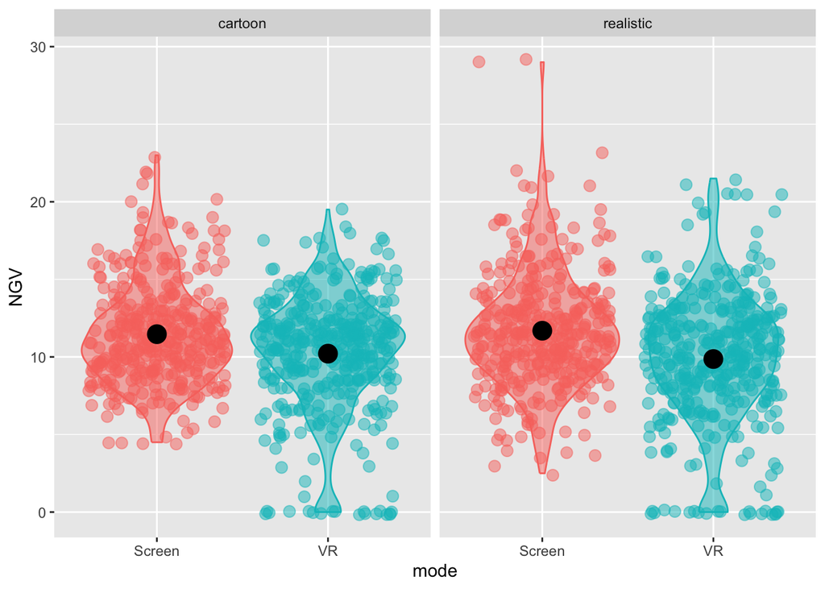

```r
ngv |>
  ggplot(aes(x = mode, y = NGV, fill = mode, colour = mode)) +
  geom_violin(alpha = 0.5) +
  geom_jitter(alpha = 0.5, size = 3) +
  stat_summary(fun = mean, geom = 'point', colour = 'black', size = 5) +
  facet_wrap(~ character) +
  theme(legend.position = 'none')
```

### Set up categorical (fixed) predictors

```r
ngv <- ngv |>
  mutate(
    mode = factor(mode),
    character = factor(character)
  )

contrasts(ngv$mode)
```

```
##        VR
## Screen  0
## VR      1
```

```r
contrasts(ngv$character)
```

```
##           realistic
## cartoon           0
## realistic         1
```

### Identify grouping variables that contribute random variability (these will be random intercepts)

```r
glimpse(ngv)
```

```
## Rows: 1,520
## Columns: 9
## $ PID       <chr> "ppt_1", "ppt_1", "ppt_1", "ppt_1", "ppt_1", "ppt_1", "ppt_1…
## $ age       <dbl> 47, 47, 47, 47, 47, 47, 47, 47, 47, 47, 47, 47, 47, 47, 47, …
## $ level     <chr> "level1", "level9", "level4", "level1", "level4", "level2", …
## $ character <fct> realistic, cartoon, cartoon, cartoon, realistic, cartoon, re…
## $ mode      <fct> Screen, Screen, Screen, Screen, Screen, Screen, Screen, Scre…
## $ P         <dbl> 2, 2, 2, 2, 2, 2, 2, 2, 2, 2, 2, 2, 2, 2, 2, 2, 2, 2, 2, 2, …
## $ N         <dbl> 3, 3, 3, 3, 3, 3, 3, 3, 3, 3, 3, 3, 3, 3, 3, 3, 3, 3, 3, 3, …
## $ M         <dbl> 3, 3, 3, 3, 3, 3, 3, 3, 3, 3, 3, 3, 3, 3, 3, 3, 3, 3, 3, 3, …
## $ NGV       <dbl> 10.5, 9.5, 10.0, 10.0, 10.5, 11.5, 11.5, 12.5, 14.5, 15.0, 1…
```

Remaining categorical or ordinal variables: - `PID` - `level` - `P` psychopathy - `N` narcissism - `M` machiavellianism

Think about data generating process:

- the dark triad traits are plausible covariates – controlled variability
- `PID` and `level` are random variability … hmm but `level` could also be controlled, do we want htings to generalise across all levels? i guess so. i guess that’s why.

### Identify what random slopes are possible in maximal model

## phase 2

## phase 3